# ZUP CASE: FATORES QUE INFLUENCIAM ATTRITION

## INTRODUÇÃO

Esse estudo se propõe a analisar, visualizar e contribuir com insights referentes ao Dataset com informações de funcionários de uma empresa e identificar os principais fatores que impactam no Attrition.

Attrition, segundo o site Investopedia (https://www.investopedia.com/terms/a/attrition.asp), 'refere à redução gradual e voluntária do número de funcionários que ocorre na medida que os empregados se aposentam ou pedem demissão e não são substituídos' pela empresa.

O Dataset em questão possui 1.470 entradas e 35 variáveis. A variável Attrition é a target variable, a qual esse estudo pretende identificar relações com as demais informações de funcionários. Os atributos que foram considerados de maior relevância para o estudo relacionado ao Attrition são: MonthlyIncome, Age, YearsAtCompany, Department, OverTime, BusinessTravel, MaritualStatus, Jobrole, EnvironmentSatisfaction, JobSatisfaction e Job Involvement.

Serão utilizados os seguintes passos: preparação e análise exploratória de dados para geração de insights e conclusões.

## PREPARAÇÃO DOS DADOS

Nessa seção são carregados os dados, verificados valores nulos, duplicados, checados os tipos dos dados e corrigidos, se necessário. Apenas os dados relevantes serão mantidos na estrutura de dados para análise posterior.

```python
#importando todos os pacotes utilizados no estudo
import numpy as np
import pandas as pd
import matplotlib.pyplot as plt
import seaborn as sb

%matplotlib inline
```

```python
#carregando o dataset
df = pd.read_excel('Dataset.xlsx', index_col=None)
df.head()
```

|  | Age | Attrition | BusinessTravel | DailyRate | Department | DistanceFromHome | Education | EducationField | EmployeeCount | EmployeeNumber | ... | RelationshipSatisfaction | StandardHours | StockOptionLevel | TotalWorkingYears | TrainingTimesLastYear | WorkLifeBalance | YearsAtCompany | YearsInCurrentRole | YearsSinceLastPromotion | YearsWithCurrManager |
| --- | --- | --- | --- | --- | --- | --- | --- | --- | --- | --- | --- | --- | --- | --- | --- | --- | --- | --- | --- | --- | --- |
| 0 | 41 | Yes | Travel_Rarely | 1102 | Sales | 1 | 2 | Life Sciences | 1 | 1 | ... | 1 | 80 | 0 | 8 | 0 | 1 | 6 | 4 | 0 | 5 |
| 1 | 49 | No | Travel_Frequently | 279 | Research & Development | 8 | 1 | Life Sciences | 1 | 2 | ... | 4 | 80 | 1 | 10 | 3 | 3 | 10 | 7 | 1 | 7 |
| 2 | 37 | Yes | Travel_Rarely | 1373 | Research & Development | 2 | 2 | Other | 1 | 4 | ... | 2 | 80 | 0 | 7 | 3 | 3 | 0 | 0 | 0 | 0 |
| 3 | 33 | No | Travel_Frequently | 1392 | Research & Development | 3 | 4 | Life Sciences | 1 | 5 | ... | 3 | 80 | 0 | 8 | 3 | 3 | 8 | 7 | 3 | 0 |
| 4 | 27 | No | Travel_Rarely | 591 | Research & Development | 2 | 1 | Medical | 1 | 7 | ... | 4 | 80 | 1 | 6 | 3 | 3 | 2 | 2 | 2 | 2 |

5 rows × 35 columns

### Visão geral do Dataset

Abaixo podemos observar que o Dataset:

- possui 1.470 linhas e 35 colunas
- não possui valores nulos
- não possui entradas duplicadas, todas as entradas são únicas
- as variáveis relacionadas a Satisfação estão codificadas com valores numéricos. Porém, por representarem categórias, deverão ser convertidas em valores categóricos e suas labels ajustadas para os respectivos significados
- as variaveis de texto estão codificadas como tipo object, porém deve ser realizada a coversão para o tipo categórico, pois este tipo usa menos memória e o oferece melhor performace de processamento
- após uma análise visual é chegada a conclusão que algumas variáveis não são relevantes para o estudo. Logo, tais variáveis devem removidas do dataset. São elas: 'DailyRate', 'EmployeeCount', 'EmployeeNumber', 'HourlyRate', 'Over18', 'MonthlyRate', 'StandardHours'

```python
#visão geral do formato do dataset e sua composição
print(df.shape)
print(df.info())
```

```
(1470, 35)
<class 'pandas.core.frame.DataFrame'>
RangeIndex: 1470 entries, 0 to 1469
Data columns (total 35 columns):
 #   Column                    Non-Null Count  Dtype
---  ------                    --------------  -----
 0   Age                       1470 non-null   int64
 1   Attrition                 1470 non-null   object
 2   BusinessTravel            1470 non-null   object
 3   DailyRate                 1470 non-null   int64
 4   Department                1470 non-null   object
 5   DistanceFromHome          1470 non-null   int64
 6   Education                 1470 non-null   int64
 7   EducationField            1470 non-null   object
 8   EmployeeCount             1470 non-null   int64
```

[output cut: 29 more lines]

```python
#procurando por dados duplicados
df.duplicated().sum()
```

```
0
```

#### Coversão de tipos

Nesta etapa é realizada a conversão de varáveis categóricas originalmente representadas por números para uma apresentação mais intuitivamente pelos seus significados. As colunas são: 'Education', 'EnvironmentSatisfaction', 'JobInvolvement','PerformanceRating', 'RelationshipSatisfaction', 'JobSatisfaction', 'WorkLifeBalance'.

```python
#criando variáveis que responsáveis pela  a correspondência numérica nos significados correspondentes
education = {1: 'Below College',2: 'College', 3: 'Bachelor', 4: 'Master', 5: 'Doctor'}
level = {1: 'Low', 2: 'Medium', 3: 'High', 4: 'Very High'}
performanceRating = {1: 'Low', 2: 'Good', 3:'Excellent', 4: 'Outstanding'}
balance = {1: 'Bad', 2: 'Good', 3: 'Better', 4: 'Best'}
```

```python
#substituindo os dados numéricos dessas colunas pelo seu correspondente significado
df['Education'] = df['Education'].replace(education)
df['EnvironmentSatisfaction'] = df['EnvironmentSatisfaction'].replace(level)
df['JobInvolvement'] = df['JobInvolvement'].replace(level)
df['JobSatisfaction'] = df['JobSatisfaction'].replace(level)
df['PerformanceRating'] = df['PerformanceRating'].replace(performanceRating)
df['RelationshipSatisfaction'] = df['RelationshipSatisfaction'].replace(level)
df['WorkLifeBalance'] = df['WorkLifeBalance'].replace(balance)
```

```python
# contagem de valores únicos, por coluna categórica
for column in df.columns:
    if df[column].dtype == object:
        print(str(column))
        print(df[column].value_counts())
        print('____________________________')
```

```
Attrition
No     1233
Yes     237
Name: Attrition, dtype: int64
____________________________
BusinessTravel
Travel_Rarely        1043
Travel_Frequently     277
Non-Travel            150
Name: BusinessTravel, dtype: int64
____________________________
Department
Research & Development    961
Sales                     446
Human Resources            63
Name: Department, dtype: int64
____________________________
Education
Bachelor         572
Master           398
College          282
Below College    170
Doctor            48
Name: Education, dtype: int64
____________________________
EducationField
Life Sciences       606
Medical             464
Marketing           159
Technical Degree    132
Other                82
Human Resources      27
Name: EducationField, dtype: int64
____________________________
EnvironmentSatisfaction
High         453
Very High    446
Medium       287
Low          284
Name: EnvironmentSatisfaction, dtype: int64
```

[output cut: 51 more lines]

```
____________________________
RelationshipSatisfaction
High         459
Very High    432
Medium       303
Low          276
Name: RelationshipSatisfaction, dtype: int64
____________________________
WorkLifeBalance
Better    893
Good      344
Best      153
Bad        80
Name: WorkLifeBalance, dtype: int64
____________________________
```

São então convertidas as variáveis do tipo object em tipos categóricos para ganho de performance

```python
#convertendo as variáveis do tipo object em categóricas
for column in df.columns:
    if df[column].dtype == object:
        df[column] = df[column].astype('category')
```

```python
#verificando os tipos das variáveis
df.dtypes
```

```
Age                            int64
Attrition                   category
BusinessTravel              category
DailyRate                      int64
Department                  category
DistanceFromHome               int64
Education                   category
EducationField              category
EmployeeCount                  int64
EmployeeNumber                 int64
EnvironmentSatisfaction     category
Gender                      category
HourlyRate                     int64
JobInvolvement              category
JobLevel                       int64
JobRole                     category
JobSatisfaction             category
MaritalStatus               category
MonthlyIncome                  int64
MonthlyRate                    int64
NumCompaniesWorked             int64
Over18                      category
OverTime                    category
PercentSalaryHike              int64
PerformanceRating           category
RelationshipSatisfaction    category
StandardHours                  int64
StockOptionLevel               int64
TotalWorkingYears              int64
TrainingTimesLastYear          int64
WorkLifeBalance             category
YearsAtCompany                 int64
YearsInCurrentRole             int64
YearsSinceLastPromotion        int64
YearsWithCurrManager           int64
dtype: object
```

#### Remoção de variáveis

Serão removidos variáveis consideradas não relevantes para o estudo. Ao final, saímos de 35 colunas para 28.

```python
#realizando o dropping
df = df.drop(['DailyRate', 'EmployeeCount', 'EmployeeNumber', 'HourlyRate', 'Over18', 'MonthlyRate', 'StandardHours'], axis = 1)
df.shape
```

```
(1470, 28)
```

### Observações estatísticas primárias

É utilizada a função describe, onde é possível gerar dados estatísticos descritivos sobre os dados números. É possível obsersar alguns pontos interessantes:

- Metade dos funcionários estão entre as idades 30 e 43 anos, a idade média de 37 anos
- A mediana do salário mensal de \$5.000
- O menor reajuste de salário é de 11\% (PercentSalaryHike)
- Na mediana as pessoas ficam 5 anos na empresa

```python
#aplicando a função describe para tirar algumas informações estatísticas
df.describe()
```

|  | Age | DistanceFromHome | JobLevel | MonthlyIncome | NumCompaniesWorked | PercentSalaryHike | StockOptionLevel | TotalWorkingYears | TrainingTimesLastYear | YearsAtCompany | YearsInCurrentRole | YearsSinceLastPromotion | YearsWithCurrManager |
| --- | --- | --- | --- | --- | --- | --- | --- | --- | --- | --- | --- | --- | --- |
| count | 1470.000000 | 1470.000000 | 1470.000000 | 1470.000000 | 1470.000000 | 1470.000000 | 1470.000000 | 1470.000000 | 1470.000000 | 1470.000000 | 1470.000000 | 1470.000000 | 1470.000000 |
| mean | 36.923810 | 9.192517 | 2.063946 | 6502.931293 | 2.693197 | 15.209524 | 0.793878 | 11.279592 | 2.799320 | 7.008163 | 4.229252 | 2.187755 | 4.123129 |
| std | 9.135373 | 8.106864 | 1.106940 | 4707.956783 | 2.498009 | 3.659938 | 0.852077 | 7.780782 | 1.289271 | 6.126525 | 3.623137 | 3.222430 | 3.568136 |
| min | 18.000000 | 1.000000 | 1.000000 | 1009.000000 | 0.000000 | 11.000000 | 0.000000 | 0.000000 | 0.000000 | 0.000000 | 0.000000 | 0.000000 | 0.000000 |
| 25% | 30.000000 | 2.000000 | 1.000000 | 2911.000000 | 1.000000 | 12.000000 | 0.000000 | 6.000000 | 2.000000 | 3.000000 | 2.000000 | 0.000000 | 2.000000 |
| 50% | 36.000000 | 7.000000 | 2.000000 | 4919.000000 | 2.000000 | 14.000000 | 1.000000 | 10.000000 | 3.000000 | 5.000000 | 3.000000 | 1.000000 | 3.000000 |
| 75% | 43.000000 | 14.000000 | 3.000000 | 8379.000000 | 4.000000 | 18.000000 | 1.000000 | 15.000000 | 3.000000 | 9.000000 | 7.000000 | 3.000000 | 7.000000 |
| max | 60.000000 | 29.000000 | 5.000000 | 19999.000000 | 9.000000 | 25.000000 | 3.000000 | 40.000000 | 6.000000 | 40.000000 | 18.000000 | 15.000000 | 17.000000 |

## Análise Exploratória de Dados

Nessa seção, para efeito de objetividade, serão feitas análises apenas da target variable (Attrition) e das variáveis independentes de maior relevância.

### Análise univariável da Attrition

Através do gráfico pizza, conseguimos verificar que 16% do total de funcionários deixaram a empresa. Nas próximas análises será estudado quais fatores mais influenciam neste percentual.

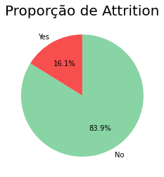

```python
#criando uma gráfico pizza para saber a proporção de Attrition
sorted_counts = df['Attrition'].value_counts()
plt.pie(sorted_counts, labels = sorted_counts.index, startangle = 90, counterclock = False, autopct="%.1f%%", colors = ['#88d4a4','#f74f4e']);

#setup the title and the labels
plt.title("Proporção de Attrition",fontsize=20);
```

### Análise de correlação das variáveis numéricas

Ao observar o gráfico heatmap abaixo, podemos chegar a algumas conclusões imediatas:

- Salário mensal e o nível da função possuem alta correlação, o que faz sentido, pois quanto mais alto o cargo, maior o salário
- Salário mensal e total de anos trabalhados possuem alta correlação
- Salário mensal e idade também possuem forte correlação, pois funcionários mais velhos, geralmente, possuem maior experiência e assim recebem valores maiores
- Idade e nível da função possuem forte correlação, pois funcionários mais velhos, geralmente, possuem maior experiência e assim assumem cargos mais altos

```python
#criando uma lista com as variáveis numéricas
numeric_vars = ['Age', 'DailyRate', 'DistanceFromHome', 'HourlyRate', 'JobLevel', 'MonthlyIncome',
       'NumCompaniesWorked', 'PercentSalaryHike',
       'StockOptionLevel', 'TotalWorkingYears',
       'TrainingTimesLastYear', 'YearsAtCompany', 'YearsInCurrentRole',
       'YearsSinceLastPromotion', 'YearsWithCurrManager']
```

[figure not shown]

```python
#criando tabela heatmap com as correlação das variáveis numericas
plt.figure(figsize = [20, 10])
sb.heatmap(df[numeric_vars].corr(), annot = True, fmt = '.1%',
           cmap = 'vlag_r', center = 0)
plt.show()
```

### Análise da distribuição das variavéis de Idade, Salário Mensal e Anos Trabalhos na Empresa

Serão análisadas as variáveis: Idade (Age), Salário Mensal (MontlhyIncome) e Anos Trabalhados na Empresa (YearsAtCompany). Para isso construímos para cada uma dessas variáveis um gráfico boxplot por Attrition e dois histograma sobrepostos dividos por Attrition.

#### Análise Age x Attition

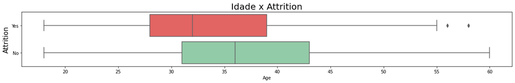

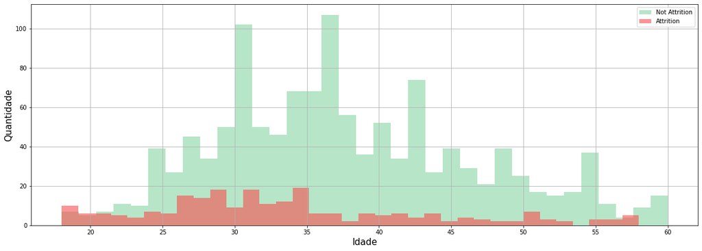

```python
# criando gráfico boxplot
colors = ['#f74f4e', '#88d4a4']
sb.set_palette(sb.color_palette(colors))
plt.figure(figsize = [20, 5])
plt.subplot(2, 1, 1)
sb.boxplot(data = df, x = 'Age', y = 'Attrition')
plt.xticks(np.arange(20, 65, 5))

#setup the title and the labels
plt.title("Idade x Attrition",fontsize=20)
plt.ylabel('Attrition',fontsize= 15);

# criando histograma
plt.figure(figsize = [20, 15])
plt.subplot(2, 1, 2)
df[df["Attrition"] == 'No']['Age'].hist(bins=35, color='#88d4a4', label='Not Attrition', alpha=0.6 )
df[df["Attrition"] == 'Yes']['Age'].hist(bins=35, color='#f74f4e', label='Attrition', alpha=0.6)
plt.xticks(np.arange(20, 65, 5))
plt.legend()
plt.xlabel("Idade",fontsize=15)
plt.ylabel('Quantidade',fontsize= 15);
```

#### Análise MonthlyIncome x Attrition

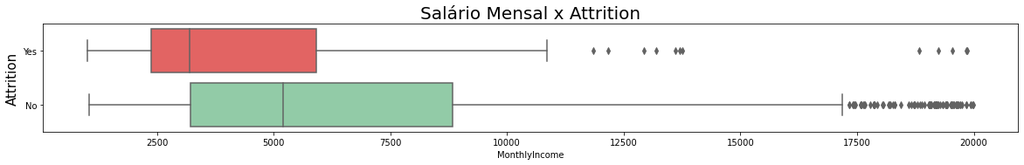

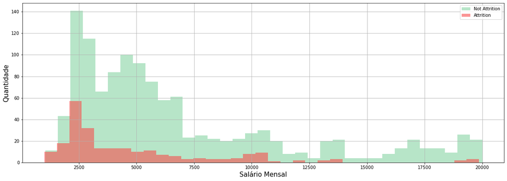

```python
# criando gráfico boxplot
colors = ['#f74f4e', '#88d4a4']
sb.set_palette(sb.color_palette(colors))
plt.figure(figsize = [20, 5])
plt.subplot(2, 1, 1)
sb.boxplot(data = df, x = 'MonthlyIncome', y = 'Attrition')
#plt.xticks(np.arange(20, 65, 5))

#setup the title and the labels
plt.title("Salário Mensal x Attrition",fontsize=20)
plt.ylabel('Attrition',fontsize= 15);

# criando histograma
plt.figure(figsize = [20, 15])
plt.subplot(2, 1, 2)
df[df["Attrition"] == 'No']['MonthlyIncome'].hist(bins=35, color='#88d4a4', label='Not Attrition', alpha=0.6 )
df[df["Attrition"] == 'Yes']['MonthlyIncome'].hist(bins=35, color='#f74f4e', label='Attrition', alpha=0.6)
plt.legend()
plt.xlabel("Salário Mensal",fontsize=15)
plt.ylabel('Quantidade',fontsize= 15);
```

#### Análise YearAtCompany x Attrition

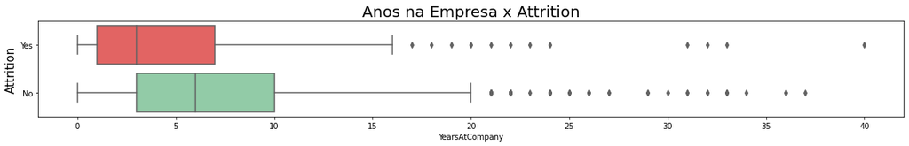

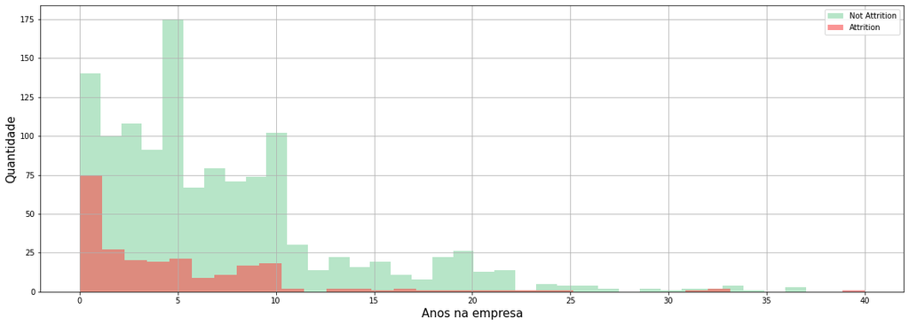

```python
# criando gráfico boxplot
colors = ['#f74f4e', '#88d4a4']
sb.set_palette(sb.color_palette(colors))
plt.figure(figsize = [20, 5])
plt.subplot(2, 1, 1)
sb.boxplot(data = df, x = 'YearsAtCompany', y = 'Attrition')
#plt.xticks(np.arange(20, 65, 5))

#setup the title and the labels
plt.title("Anos na Empresa x Attrition",fontsize=20)
plt.ylabel('Attrition',fontsize= 15);

# criando histograma
plt.figure(figsize = [20, 15])
plt.subplot(2, 1, 2)
df[df["Attrition"] == 'No']['YearsAtCompany'].hist(bins=35, color='#88d4a4', label='Not Attrition', alpha=0.6 )
df[df["Attrition"] == 'Yes']['YearsAtCompany'].hist(bins=35, color='#f74f4e', label='Attrition', alpha=0.6)
plt.legend()
plt.xlabel("Anos na empresa",fontsize=15)
plt.ylabel('Quantidade',fontsize= 15);
```

#### Análise MontlhyIncome x Age x Attrition

Abaixo foi criado uma gráfico de correlação entre as variáveis de Idade, Salário mensal e Attrition

- Confirma-se que funcionários mais jovens ganham menos e saem mais
- Com o aumento da idade, é possível observar que os funcionários começam a ganhar mais (correlação positiva entre MonthlyIncome e Age) e diminui o Attrition

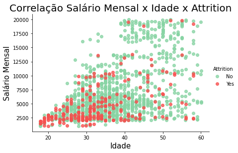

```python
# criando scatterplot para mostrar correlação das três variáveis
colors = ['#88d4a4','#f74f4e']
sb.set_palette(sb.color_palette(colors))
g = sb.FacetGrid(data = df, hue = 'Attrition',hue_order = ['No','Yes'], height = 4, aspect = 1.5)
g = g.map(sb.regplot, 'Age', 'MonthlyIncome', x_jitter = 0.04, fit_reg = False)
g.add_legend()

#colocando titulo e eixos
plt.title("Correlação Salário Mensal x Idade x Attrition",fontsize=20)
plt.xlabel("Idade",fontsize=15)
plt.ylabel('Salário Mensal',fontsize= 15);
```

Abaixo foi criado uma gráfico de correlação entre as variáveis de Anos Trabalhados na empresa, Salário mensal e Attrition

- É possível observar um elevado nível de Attrition dentre os funcionários com menos de 5 anos de empresa e que ganham até $5.000
- A partir de 10 anos de empresa é nitído a queda do Attrition
- A partir de 20 anos de empresa é clara uma média salarial maior em relação aos com menos tempo de empresa e, consequentemente, no nível de attrition menor no grupo com mais de 20 anos de empresa

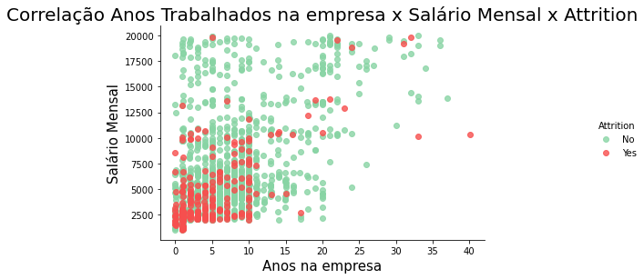

```python
# criando scatter plot para mostrar correlação das três variáveis mencionadas
colors = ['#88d4a4','#f74f4e']
sb.set_palette(sb.color_palette(colors))
g = sb.FacetGrid(data = df, hue = 'Attrition', hue_order = ['No','Yes'], height = 4, aspect = 1.5)
g = g.map(sb.regplot, 'YearsAtCompany', 'MonthlyIncome', x_jitter = 0.04, fit_reg = False)
g.add_legend()

#colocando titulo e eixos
plt.title("Correlação Anos Trabalhados na empresa x Salário Mensal x Attrition",fontsize=20)
plt.xlabel("Anos na empresa",fontsize=15)
plt.ylabel('Salário Mensal',fontsize= 15);
```

### Análise de satisfação e envolvimento

Aqui serão analisadas variáveis referentes a Satisfação e nível de Envolvimento dos funcionários. Tais são: EnvironmentSatisfaction, Jobsatisfaction e JobInvolvement.

```python
#criando função que irá adicionar as porcentagens acima de cada barra
def with_hue(plot, feature, categories, hue_categories):
    Number_of_categories = len(categories)
    a = [p.get_height() for p in plot.patches]
    patch = [p for p in plot.patches]
    for i in range(Number_of_categories):
        total = feature.value_counts()[categories[i]]
        for j in range(hue_categories):
            percentage = '{:.1f}%'.format(100 * a[(j*Number_of_categories + i)]/total)
            x = patch[(j*Number_of_categories + i)].get_x() + patch[(j*Number_of_categories + i)].get_width() / 2 - 0.15
            y = patch[(j*Number_of_categories + i)].get_y() + patch[(j*Number_of_categories + i)].get_height()
            ax.annotate(percentage, (x-.01, y+7), size = 12)
    plt.show()
```

#### Análise EnvironmentSatisfaction x Attrition

Abaixo será analisada a satisfação dos funcionários em relação ao Ambiente de Trabalho e a permanência na empresa.

- Pode-se observar pelo gráfico que 25% dos funcionários que estão com satisfação baixa saíram
- A proporção de saída diminui com o aumento da satisfação

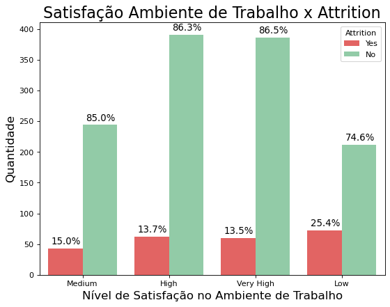

```python
#criando gráfico de barras com duas variáveis
plt.figure(figsize=(8, 6), dpi=80)
colors = ['#f74f4e','#88d4a4']
sb.set_palette(sb.color_palette(colors))
ax = sb.countplot(data = df, x = 'EnvironmentSatisfaction', hue = 'Attrition')

#setup the title and the labels
plt.title("Satisfação Ambiente de Trabalho x Attrition",fontsize=20)
plt.xlabel("Nível de Satisfação no Ambiente de Trabalho",fontsize=15)
plt.ylabel('Quantidade',fontsize= 15);

with_hue(ax,df.EnvironmentSatisfaction, ['Medium', 'High', 'Very High', 'Low'], 2)
```

#### Análise JobSatisfaction x Attrition

Abaixo será analisada a satisfação do funcionário em relação ao seu trabalho e sua permanência na empresa.

- Pode-se observar pelo gráfico que 23% dos funcionários que estão com satisfação baixa saíram
- Em geral, a proporção de saída diminui com o aumento da satisfação com o trabalho

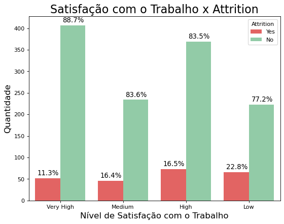

```python
#criando gráfico de barras com duas variáveis
plt.figure(figsize=(8, 6), dpi=80)
colors = ['#f74f4e','#88d4a4']
sb.set_palette(sb.color_palette(colors))
ax = sb.countplot(data = df, x = 'JobSatisfaction', hue = 'Attrition')

#setup the title and the labels
plt.title("Satisfação com o Trabalho x Attrition",fontsize=20)
plt.xlabel("Nível de Satisfação com o Trabalho",fontsize=15)
plt.ylabel('Quantidade',fontsize= 15);

with_hue(ax,df.JobSatisfaction, ['Very High','Medium', 'High', 'Low'], 2)
```

#### Análise JobInvolvement x Attrition

Abaixo será analisada a envolvimento do funcionário em relação ao seu trabalho e sua permanência na empresa.

- Pode-se observar pelo gráfico que 34% dos funcionários que estão com envolvimento baixo saíram
- A proporção de saída diminui com o aumento do envolvimento

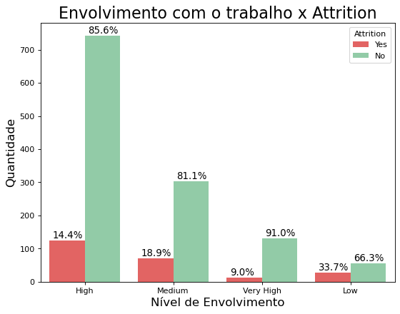

```python
#criando gráfico de barras com duas variáveis
plt.figure(figsize=(8, 6), dpi=80)
colors = ['#f74f4e','#88d4a4']
sb.set_palette(sb.color_palette(colors))
ax = sb.countplot(data = df, x = 'JobInvolvement', hue = 'Attrition')

#setup the title and the labels
plt.title("Envolvimento com o trabalho x Attrition",fontsize=20)
plt.xlabel("Nível de Envolvimento",fontsize=15)
plt.ylabel('Quantidade',fontsize= 15);

with_hue(ax,df.JobInvolvement, ['High','Medium','Very High','Low'], 2)
```

#### Análise MaritalStatus x Attrition

Abaixo será analisada o estado civil dos funcionários e sua permanência na empresa.

- A Attrition é maior nos funcionários com estado civil de solteiros, 26%
- Em comparação, a porcentagem de saída dos outros estados civis são menores

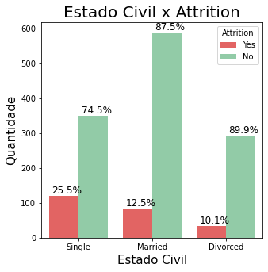

```python
#criando gráfico sobre MaritualStatus e sua proporção de Attrition
plt.figure(figsize = [5, 5])
colors = ['#f74f4e','#88d4a4']
sb.set_palette(sb.color_palette(colors))
ax = sb.countplot(data = df, x = 'MaritalStatus', hue = 'Attrition')

#setup the title and the labels
plt.title("Estado Civil x Attrition",fontsize=20)
plt.xlabel("Estado Civil",fontsize=15)
plt.ylabel('Quantidade',fontsize= 15);

with_hue(ax,df.MaritalStatus, ['Single', 'Married', 'Divorced'], 2)
```

### Análise das variáveis de Overtime e Business Travel

Aqui serão analisados as variáveis referentes a funcionários que fazem hora extra e os que viajam a trabalho

#### Análise Overtime x Attrition

Aqui será analisada a influência da realização de Horas Extras

- Pode-se ver claramente no gráfico que os funcionários que realização horas extras tem uma propoção alta de Attrition (30%) se comparado aos que não fazem horas extras.

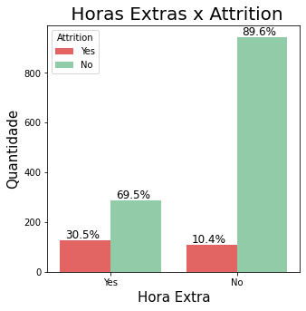

```python
#criando gráfico de barras para variável BusinessTravel com relação a Attrition
plt.figure(figsize = [5, 5])
colors = ['#f74f4e','#88d4a4']
sb.set_palette(sb.color_palette(colors))
ax = sb.countplot(data = df, x = 'OverTime', hue = 'Attrition')

plt.title(" Horas Extras x Attrition",fontsize=20)
plt.xlabel("Hora Extra",fontsize=15)
plt.ylabel('Quantidade',fontsize= 15);

with_hue(ax,df.OverTime, ['Yes', 'No'], 2)
```

#### Análise BusinessTravel x Attrition

Aqui será analisada a influência da realização de Viagens a Trabalho

- Pode-se ver no gráfico que os funcionários que Viajam a trabalho frequentemente tem uma porcentagem maior de Attrition (25%)
- A porcentagem diminui para os que viagem raramente e os que não viajam apresentam uma proporção menor de evasão

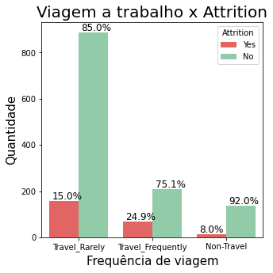

```python
#criando gráfico de barras para variável BusinessTravel com relação a Attrition
#sb.countplot(data = df, x = 'BusinessTravel', hue = 'Attrition');

plt.figure(figsize = [5, 5])
colors = ['#f74f4e','#88d4a4']
sb.set_palette(sb.color_palette(colors))
ax = sb.countplot(data = df, x = 'BusinessTravel', hue = 'Attrition')

plt.title("Viagem a trabalho x Attrition",fontsize=20)
plt.xlabel("Frequência de viagem",fontsize=15)
plt.ylabel('Quantidade',fontsize= 15);

with_hue(ax,df.BusinessTravel, ['Travel_Rarely', 'Travel_Frequently', 'Non-Travel'],2)
```

### Análise sobre função, departamento e números de companhias trabalhadas

#### Análise JobRole x Attrition

Abaixo será analisada a função dos funcionários e sua permanência na empresa

- Os cargos de gestão e direção apresentam menores taxas de saídas
- Os cargos de vendas apresentam alta taxa de saída, em especial o Sales Representative (40%)
- Em seguida, estão os cargos de Técnico de Laboratório (24%) e Recursos humanos (23%) com maiores níveis de Attrition
- Sales Executive possui a quarta maior taxa de saída (17,5%), porém devido à quantidade absoluta de funcionários, apresenta o segundo maior número de funcionários que saem

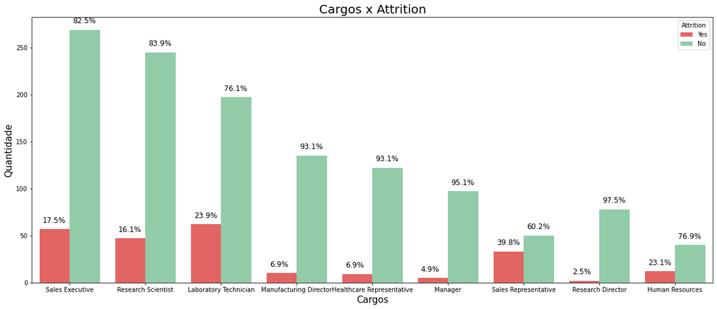

```python
#criação de gráfico sobre cada JobRole dividos por Attrition
plt.figure(figsize = [20, 8])
colors = ['#f74f4e','#88d4a4']
sb.set_palette(sb.color_palette(colors))
ax = sb.countplot(data = df, x = 'JobRole', hue = 'Attrition')

#setup the title and the labels
plt.title("Cargos x Attrition",fontsize=20)
plt.xlabel("Cargos",fontsize=15)
plt.ylabel('Quantidade',fontsize= 15);

with_hue(ax,df.JobRole, ['Sales Executive', 'Research Scientist', 'Laboratory Technician','Manufacturing Director','Healthcare Representative',
'Manager', 'Sales Representative', 'Research Director', 'Human Resources'],2)
```

#### Análise Department x Salário Médio Mensal x Attrition

Abaixo será analisado o Salário médio mensal por Departamento e a Permanência na empresa

- É possível observar que em todos os departamentos os funcionários que saem da empresa possuem em média salários mais baixos dos que permanecem

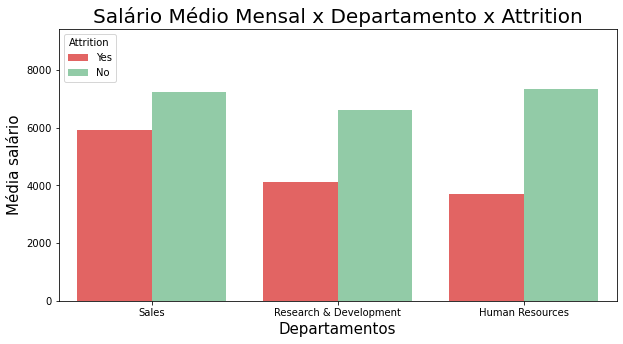

```python
#criação de gráfico sobre cada Departamento em relação ao salário médio mensal dividos por Attrition
plt.figure(figsize = [10, 5])
colors = ['#f74f4e','#88d4a4']
sb.set_palette(sb.color_palette(colors))
sb.barplot(data = df, x = 'Department', y = 'MonthlyIncome', hue = 'Attrition', errwidth=0)

#setup the title and the labels
plt.title("Salário Médio Mensal x Departamento x Attrition",fontsize=20)
plt.xlabel("Departamentos",fontsize=15)
plt.ylabel('Média salário',fontsize= 15);
```

## Conclusão

Após avalisar as variáveis propostas no ínico desse estudo para tentar explicar os fatores que influenciam no Attrition chegou-se nas seguintes conclusões:

- Em geral funcionários mais jovens, com menos tempo de empresa e salários mais baixos tendem a apresentar maiores níveis de Attrition, possivelmente relacionados à falta de experiência e uma eventual falta de plano de carreira e retenção por parte da empresa.
- O Salário Mensal (MonthlyIncome) apresentou forte influência no Attrition. Em todos os departamentos os salários mensais médios dos que saíram são menores dos os salários dos funcionários remanescentes. Logo, quanto maior o salário mensal, menor a saída de funcionários.
- A Satisfação, seja com o ambiente de trabalho (EnvironmentSatisfaction), com a função (JobSatisfaction) e o nível de envolvimento com o trabalho (JobInvolvement), tem forte influência na retenção de funcionários. Assim, quanto mais satisfeito e engajado o funcionário, menores as chances dele vir a sair da empresa.
- O estado civil (MaritualStatus), curiosamente, foi um dos fatores de destaque para entender a saída de funcionários. Os solteiros apresentaram uma maior evasão, em comparação com os casados e divorciados. Possivelmente, este fato seja explicado pela maior flexibilidade de mudanças por parte dos solteiros.
- Trabalhar horas extras (OverTime) e viajar a trabalho (BusinessTravel) são também fatores que pesam consideravelmente no entendimento do Attrition. Funcionários que fazem hora extra e que viajam com maior frequência têm maiores chances de sair da empresa.
- Com relação aos cargos (JobRole), alguns apresentam maior Attrition do que outros, são eles: Sales Representative, Sales Executive, Laboratory Technician e Human Resources. Cargos de gestão e direção possuem os menores níveis de evasão. Vale destacar que o cargo de Sales Representative possue uma alta proporção de saída (40%).